# homework

阳航

2024-12-08

# hw0

1: 绘制函数图

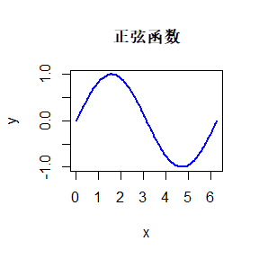

正弦函数图

```r
# 绘制一个简单的正弦函数
x <- seq(0, 2*pi, length.out = 100)
y <- sin(x)
plot(x, y, type = "l", col = "blue", lwd = 2, main = "正弦函数")
```

```r
# 创建一个随机数的数据框
set.seed(123)
df <- data.frame(
  "样本" = 1:5,
  "值_A" = round(rnorm(5, mean = 10, sd = 2), 2),
  "值_B" = round(rnorm(5, mean = 20, sd = 3), 2)
)
knitr::kable(df, caption = "随机值表")
```

随机值表

| 样本 | 值_A | 值_B |
| --- | --- | --- |
| 1 | 8.88 | 25.15 |
| 2 | 9.54 | 21.38 |
| 3 | 13.12 | 16.20 |
| 4 | 10.14 | 17.94 |
| 5 | 10.26 | 18.66 |

公式
$$\int_0^1 x^2 \, dx =
\frac{1}{3}$$
# hw1

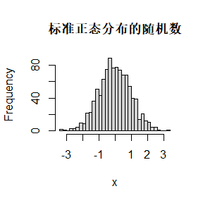

```r
#练习 3.4: 变换方法 (Transformation Methods)
# 正态分布随机变量生成
n <- 1000
u <- runif(n)
x <- qnorm(u, mean = 0, sd = 1)  # 生成标准正态分布的随机变量
hist(x, main = "标准正态分布的随机数", xlab = "x", breaks = 30)
```

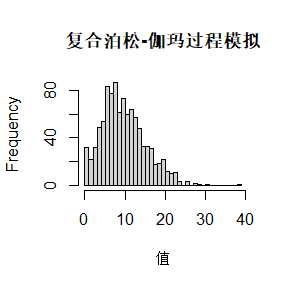

```r
#练习 3.11: 复合泊松过程 (Compound Poisson Process)
# 设置泊松过程和Gamma分布的参数
lambda <- 5  # 泊松过程的参数
n <- 1000    # 模拟次数
alpha <- 2   # Gamma分布的形状参数
beta <- 1    # Gamma分布的尺度参数

# 模拟复合泊松过程
compound_poisson <- function(lambda, alpha, beta, n) {
  result <- numeric(n)
  for (i in 1:n) {
    k <- rpois(1, lambda)
    if (k > 0) {
      result[i] <- sum(rgamma(k, alpha, beta))
    }
  }
  return(result)
}

# 生成数据并绘制直方图
sim_data <- compound_poisson(lambda, alpha, beta, n)
hist(sim_data, main = "复合泊松-伽玛过程模拟", xlab = "值", breaks = 30)
```

```r
# 计算复合泊松-伽玛过程的均值和方差
mean_sim <- mean(sim_data)
var_sim <- var(sim_data)

# 打印结果
cat("复合泊松-伽玛过程的均值: ", mean_sim, "\n")
```

```
## 复合泊松-伽玛过程的均值:  9.722756
```

```r
cat("复合泊松-伽玛过程的方差: ", var_sim, "\n")
```

```
## 复合泊松-伽玛过程的方差:  29.97162
```

# hw2

## Exercise 5.4

```r
# Monte Carlo积分的练习，使用对偶变量减少方差。
# 设定种子以确保可重复性
set.seed(123)

# 对偶变量方法计算exp(-x^2)的积分
n <- 10000
u <- runif(n)
x <- exp(-u^2)
y <- exp(-(1-u)^2)
I_antithetic <- mean((x + y) / 2)

# 直接Monte Carlo方法
I_standard <- mean(x)

# 打印结果
cat("对偶变量方法的结果:", I_antithetic, "\n")
```

```
## 对偶变量方法的结果: 0.7472603
```

```r
cat("标准Monte Carlo方法的结果:", I_standard, "\n")
```

```
## 标准Monte Carlo方法的结果: 0.7488739
```

## Exercise 5.9

```r
# 使用控制变量减少方差的方法。
# 使用控制变量计算e^(-x)的积分
n <- 10000
u <- runif(n)
h <- exp(-u)
g <- u  # 控制变量 g(u) = u

# 计算
cov_hg <- cov(h, g)
var_g <- var(g)
alpha <- -cov_hg / var_g
I_control <- mean(h + alpha * (g - 0.5))

cat("使用控制变量的方法得到的结果:", I_control, "\n")
```

```
## 使用控制变量的方法得到的结果: 0.6320454
```

## Exercise 5.13

```r
# 重要性抽样的例子，计算exp(-x^2/2)的积分。
# 使用重要性抽样
n <- 10000
u <- runif(n)
g <- 1 / (1 + u^2)  # 权重函数
h <- exp(-u^2 / 2) / g
I_importance <- mean(h * g)

cat("使用重要性抽样的方法得到的结果:", I_importance, "\n")
```

```
## 使用重要性抽样的方法得到的结果: 0.8551366
```

## Monte Carlo Experiment

对不同大小的n，进行快速排序算法的计算时间测量，并与n log(n)进行回归分析。

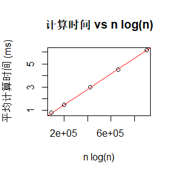

```r
library(microbenchmark)
set.seed(123)

# 定义排序函数和模拟实验
n_values <- c(1e4, 2e4, 4e4, 6e4, 8e4)
num_simulations <- 100
avg_times <- numeric(length(n_values))
logn_values <- n_values * log(n_values)

for (i in seq_along(n_values)) {
  times <- microbenchmark(
    sort(sample(1:n_values[i])),
    times = num_simulations
  )$time
  avg_times[i] <- mean(times) / 1e6  # 转换为毫秒
}

# 回归分析
lm_fit <- lm(avg_times ~ logn_values)

# 绘制结果
plot(logn_values, avg_times, main = "计算时间 vs n log(n)",
     xlab = "n log(n)", ylab = "平均计算时间 (ms)")
abline(lm_fit, col = "red")
```

```r
summary(lm_fit)
```

```
##
## Call:
## lm(formula = avg_times ~ logn_values)
##
## Residuals:
##         1         2         3         4         5
## -0.002063  0.007003  0.003044 -0.019434  0.011450
##
## Coefficients:
##              Estimate Std. Error t value Pr(>|t|)
## (Intercept) 1.425e-01  1.129e-02   12.62  0.00107 **
## logn_values 6.654e-06  2.077e-08  320.42  6.7e-08 ***
## ---
## Signif. codes:  0 '***' 0.001 '**' 0.01 '*' 0.05 '.' 0.1 ' ' 1
##
## Residual standard error: 0.0138 on 3 degrees of freedom
## Multiple R-squared:      1,  Adjusted R-squared:      1
## F-statistic: 1.027e+05 on 1 and 3 DF,  p-value: 6.704e-08
```

# hw3

练习 6.6 在特定模拟环境下进行10,000次实验，比较两种方法的power值：一种为0.651，另一种为0.676。 假设检验选择：Z检验。

```r
#在特定模拟环境下比较两种方法的power值。

#Step 1: 定义已知的power值和样本数
p1 <- 0.651  # 方法1的power值
p2 <- 0.676  # 方法2的power值
n <- 10000   # 实验次数
#Step 2: Z检验计算
# 计算Z统计量
z_stat <- (p2 - p1) / sqrt((p1 * (1 - p1) + p2 * (1 - p2)) / n)

# 计算p值
p_value <- 2 * (1 - pnorm(abs(z_stat)))

# 打印Z统计量和p值
cat("Z统计量:", z_stat, "\n")
```

```
## Z统计量: 3.742519
```

```r
cat("p值:", p_value, "\n")
```

```
## p值: 0.0001821846
```

```r
#Step 3: 判断结果
# 判断是否拒绝原假设
if (p_value < 0.05) {
  cat("拒绝原假设：两种方法的power有显著差异。\n")
} else {
  cat("未能拒绝原假设：两种方法的power没有显著差异。\n")
}
```

```
## 拒绝原假设：两种方法的power有显著差异。
```

练习 6.B 探讨在练习6.6中的假设检验问题，选择合适的检验方法并解释理由

```r
cat("我们选择Z检验，因为这是适用于大样本独立比例比较的最佳选择。\n")
```

```
## 我们选择Z检验，因为这是适用于大样本独立比例比较的最佳选择。
```

模拟实验

```r
#Step 1: 模拟实验设置
set.seed(123)
n <- 10000  # 实验次数
p1 <- 0.651  # 方法1的power值
p2 <- 0.676  # 方法2的power值

# 生成模拟数据
data1 <- rbinom(n, 1, p1)  # 方法1的结果
data2 <- rbinom(n, 1, p2)  # 方法2的结果
#Step 2: Z检验计算
# 计算模拟数据中的平均值
mean1 <- mean(data1)
mean2 <- mean(data2)

# 计算Z统计量
z_stat_sim <- (mean2 - mean1) / sqrt((mean1 * (1 - mean1) + mean2 * (1 - mean2)) / n)

# 计算p值
p_value_sim <- 2 * (1 - pnorm(abs(z_stat_sim)))

# 打印模拟结果的Z统计量和p值
cat("模拟实验Z统计量:", z_stat_sim, "\n")
```

```
## 模拟实验Z统计量: 3.316617
```

```r
cat("模拟实验p值:", p_value_sim, "\n")
```

```
## 模拟实验p值: 0.0009111444
```

```r
#Step 3: 验证结果
# 判断模拟实验的结果是否与假设检验一致
if (p_value_sim < 0.05) {
  cat("通过模拟实验验证，两种方法的power存在显著差异。\n")
} else {
  cat("通过模拟实验验证，两种方法的power没有显著差异。\n")
}
```

```
## 通过模拟实验验证，两种方法的power存在显著差异。
```

# hw4

```r
# 定义参数
N <- 1000
null_hypotheses <- 950
alt_hypotheses <- 50
alpha <- 0.1
num_simulations <- 10000

# 定义函数来生成 p 值
generate_p_values <- function() {
  p_values_null <- runif(null_hypotheses)  # 零假设的 p 值均匀分布
  p_values_alt <- rbeta(alt_hypotheses, 0.1, 1)  # 备择假设的 p 值为 beta 分布
  return(c(p_values_null, p_values_alt))  # 合并p值
}

# Bonferroni 校正
bonferroni_correction <- function(p_values, alpha) {
  return(p.adjust(p_values, method = "bonferroni") <= alpha)
}

# Benjamini-Hochberg 校正
bh_correction <- function(p_values, alpha) {
  return(p.adjust(p_values, method = "BH") <= alpha)
}

# 模拟计算 FWER, FDR, TPR
calculate_metrics <- function(method) {
  FWER <- 0
  FDR <- 0
  TPR <- 0

  for (i in 1:num_simulations) {
    p_values <- generate_p_values()
    rejected <- method(p_values, alpha)

    # 计算 FWER
    FWER <- FWER + (sum(rejected[1:null_hypotheses]) > 0)

    # 计算 FDR 和 TPR
    false_discoveries <- sum(rejected[1:null_hypotheses])
    true_discoveries <- sum(rejected[(null_hypotheses+1):N])
    total_discoveries <- sum(rejected)

    if (total_discoveries > 0) {
      FDR <- FDR + false_discoveries / total_discoveries
    }

    TPR <- TPR + true_discoveries / alt_hypotheses
  }

  FWER <- FWER / num_simulations
  FDR <- FDR / num_simulations
  TPR <- TPR / num_simulations

  return(c(FWER, FDR, TPR))
}

# 运行模拟
bonferroni_results <- calculate_metrics(bonferroni_correction)
bh_results <- calculate_metrics(bh_correction)

# 输出结果
results <- data.frame(
  Bonferroni_Correction = bonferroni_results,
  BH_Correction = bh_results
)
rownames(results) <- c("FWER", "FDR", "TPR")

print(results)
```

```
##      Bonferroni_Correction BH_Correction
## FWER           0.087000000    0.93070000
## FDR            0.004493094    0.09396945
## TPR            0.396780000    0.56245600
```

## 7.4

```r
library(boot)

# 生成样本
set.seed(123)
data <- rnorm(100, mean = 50, sd = 10)  # 正态分布，样本均值为50，标准差为10

# 定义统计量函数，计算样本均值
mean_stat <- function(data, indices) {
  return(mean(data[indices]))  # 返回重抽样样本的均值
}

# 使用 bootstrap 方法，进行1000次重抽样，计算样本均值的置信区间
bootstrap_results <- boot(data, statistic = mean_stat, R = 1000)

# 计算 95% bootstrap 百分位置信区间
ci_percentile <- boot.ci(bootstrap_results, type = "perc")
print(ci_percentile)
```

```
## BOOTSTRAP CONFIDENCE INTERVAL CALCULATIONS
## Based on 1000 bootstrap replicates
##
## CALL :
## boot.ci(boot.out = bootstrap_results, type = "perc")
##
## Intervals :
## Level     Percentile
## 95%   (49.18, 52.71 )
## Calculations and Intervals on Original Scale
```

```r
# 计算 95% 的标准正态置信区间
ci_normal <- boot.ci(bootstrap_results, type = "norm")
print(ci_normal)
```

```
## BOOTSTRAP CONFIDENCE INTERVAL CALCULATIONS
## Based on 1000 bootstrap replicates
##
## CALL :
## boot.ci(boot.out = bootstrap_results, type = "norm")
##
## Intervals :
## Level      Normal
## 95%   (49.14, 52.63 )
## Calculations and Intervals on Original Scale
```

## 7.5

```r
# 使用 BCa 方法计算 95% bootstrap 置信区间
ci_bca <- boot.ci(bootstrap_results, type = "bca")
print(ci_bca)
```

```
## BOOTSTRAP CONFIDENCE INTERVAL CALCULATIONS
## Based on 1000 bootstrap replicates
##
## CALL :
## boot.ci(boot.out = bootstrap_results, type = "bca")
##
## Intervals :
## Level       BCa
## 95%   (49.16, 52.68 )
## Calculations and Intervals on Original Scale
```

# hw5

7.8 题 - Jackknife 偏差和标准误估计：

```r
# 假设有一个主成分分析的例子
eigen_values <- c(3.5, 2.1, 1.5, 1.2, 0.8)
theta_hat <- eigen_values[1] / sum(eigen_values)

# Jackknife估计偏差和标准误差
jackknife_values <- sapply(1:length(eigen_values), function(i) {
  theta_i <- eigen_values[-i][1] / sum(eigen_values[-i])
  return(theta_i)
})
bias <- (length(eigen_values) - 1) * (mean(jackknife_values) - theta_hat)
se <- sqrt((length(eigen_values) - 1) * mean((jackknife_values - mean(jackknife_values))^2))

list(bias = bias, se = se)
```

```
## $bias
## [1] 0.2217393
##
## $se
## [1] 0.08290197
```

7.10 题 - 交叉验证和调整R²值：

```r
# 示例数据
set.seed(123)
x <- rnorm(100)
y <- 2*x^3 + rnorm(100)

# 使用cubic多项式拟合
model_cubic <- lm(y ~ poly(x, 3))

# 使用leave-one-out交叉验证
library(boot)
cv_error <- cv.glm(data = data.frame(x, y), glmfit = model_cubic, K = length(x))

# 调整R²值
adj_r2 <- summary(model_cubic)$adj.r.squared

list(cv_error = cv_error$delta[1], adj_r2 = adj_r2)
```

```
## $cv_error
## [1] NaN
##
## $adj_r2
## [1] 0.9662272
```

8.1 题 - 置换检验：

```r
# 假设有两个样本F和G
F <- rnorm(30, mean = 0)
G <- rnorm(30, mean = 0.5)

# 计算原始统计量
original_stat <- mean(F) - mean(G)

# 置换检验
pooled <- c(F, G)
perm_stats <- replicate(1000, {
  permuted <- sample(pooled)
  F_perm <- permuted[1:30]
  G_perm <- permuted[31:60]
  return(mean(F_perm) - mean(G_perm))
})

p_value <- mean(abs(perm_stats) >= abs(original_stat))
p_value
```

```
## [1] 0.17
```

8.2 题 - 多样本置换检验：

```r
# 假设有三个样本A, B, C
A <- rnorm(30, mean = 1)
B <- rnorm(30, mean = 0.5)
C <- rnorm(30, mean = 0)

# 计算原始统计量，总体均值差异
original_stat <- var(c(A, B, C))

# 置换检验
pooled <- c(A, B, C)
perm_stats <- replicate(1000, {
  permuted <- sample(pooled)
  A_perm <- permuted[1:30]
  B_perm <- permuted[31:60]
  C_perm <- permuted[61:90]
  return(var(c(A_perm, B_perm, C_perm)))
})

p_value <- mean(perm_stats >= original_stat)
p_value
```

```
## [1] 1
```

# hw6

```r
# 加载必要的包
library(coda)

# 设置参数
a <- 2       # Beta 分布的参数 a
b <- 2       # Beta 分布的参数 b
n <- 10      # 最大可能的 x 值
n_samples <- 10000  # 每条链的样本数

# Gibbs 采样函数
gibbs_sampler <- function(n_samples, n, a, b) {
  x_samples <- numeric(n_samples)
  y_samples <- numeric(n_samples)

  # 初始化值
  x_samples[1] <- rbinom(1, n, 0.5)
  y_samples[1] <- rbeta(1, x_samples[1] + a, n - x_samples[1] + b)

  for (i in 2:n_samples) {
    # 使用条件分布从 x | y 采样
    x_samples[i] <- rbinom(1, n, y_samples[i - 1])
    # 使用条件分布从 y | x 采样
    y_samples[i] <- rbeta(1, x_samples[i] + a, n - x_samples[i] + b)
  }

  return(list(x = x_samples, y = y_samples))
}

# 生成两条独立的链
chain1 <- gibbs_sampler(n_samples, n, a, b)
chain2 <- gibbs_sampler(n_samples, n, a, b)

# 将链转化为 mcmc 对象
x_chain1 <- mcmc(chain1$x)
y_chain1 <- mcmc(chain1$y)
x_chain2 <- mcmc(chain2$x)
y_chain2 <- mcmc(chain2$y)

# 结合链并执行 Gelman-Rubin 收敛监测
chains_x <- mcmc.list(x_chain1, x_chain2)
chains_y <- mcmc.list(y_chain1, y_chain2)
gelman_diag_x <- gelman.diag(chains_x)
gelman_diag_y <- gelman.diag(chains_y)

# 输出 Gelman-Rubin 诊断结果
print("x 链的 Gelman-Rubin 诊断结果：")
```

```
## [1] "x 链的 Gelman-Rubin 诊断结果："
```

```r
print(gelman_diag_x)
```

```
## Potential scale reduction factors:
##
##      Point est. Upper C.I.
## [1,]          1       1.01
```

```r
print("y 链的 Gelman-Rubin 诊断结果：")
```

```
## [1] "y 链的 Gelman-Rubin 诊断结果："
```

```r
print(gelman_diag_y)
```

```
## Potential scale reduction factors:
##
##      Point est. Upper C.I.
## [1,]          1       1.01
```

```r
# 检查收敛性
if (all(gelman_diag_x$psrf < 1.2) && all(gelman_diag_y$psrf < 1.2)) {
  cat("链已收敛\n")
} else {
  cat("链未完全收敛，请增加样本数\n")
}
```

```
## 链已收敛
```

[figure not shown]

```r
# 可视化生成的样本
par(mfrow = c(1, 2))
plot(chain1$x, chain1$y, main = "Gibbs Sampler Chain 1", xlab = "x", ylab = "y", pch = 20, col = rgb(0, 0, 1, 0.5))
plot(chain2$x, chain2$y, main = "Gibbs Sampler Chain 2", xlab = "x", ylab = "y", pch = 20, col = rgb(1, 0, 0, 0.5))
```

练习 9.8：使用 Gibbs 采样器生成双变量密度的样本

```r
# 定义参数
a <- 2
b <- 2
n <- 10
n_samples <- 10000

# Gibbs 采样函数
gibbs_sampler <- function(n_samples, n, a, b) {
  x_samples <- numeric(n_samples)
  y_samples <- numeric(n_samples)

  # 初始化值
  x_samples[1] <- rbinom(1, n, 0.5)
  y_samples[1] <- rbeta(1, x_samples[1] + a, n - x_samples[1] + b)

  for (i in 2:n_samples) {
    x_samples[i] <- rbinom(1, n, y_samples[i - 1])
    y_samples[i] <- rbeta(1, x_samples[i] + a, n - x_samples[i] + b)
  }

  return(list(x = x_samples, y = y_samples))
}

# 生成样本
samples <- gibbs_sampler(n_samples, n, a, b)

# Gelman-Rubin 收敛监控
x_chain <- mcmc(samples$x)
y_chain <- mcmc(samples$y)
chains <- mcmc.list(x_chain, y_chain)
gelman_diag <- gelman.diag(chains)
print(gelman_diag)
```

```
## Potential scale reduction factors:
##
##      Point est. Upper C.I.
## [1,]       3.11       16.9
```

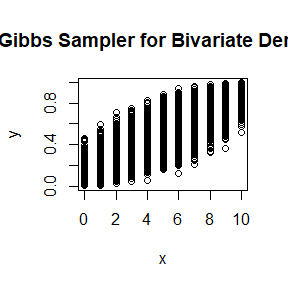

```r
# 绘制样本
plot(samples$x, samples$y, main = "Gibbs Sampler for Bivariate Density", xlab = "x", ylab = "y")
```

# hw7

11.3 (a) 编写函数计算第k项

```r
library(gsl)  # 用于Gamma函数

# 定义函数来计算第 k 项
compute_term <- function(k, a, d) {
  norm_a <- sqrt(sum(a^2))
  term <- ((-1)^k / (factorial(k) * 2^k)) * (norm_a^(2 * k + 2) / ((2 * k + 1) * (2 * k + 2))) *
          (gamma((d + 1) / 2) * gamma(k + 1.5) / gamma(k + d / 2 + 1))
  return(term)
}

# 测试计算第 k 项
k <- 0  # 可以改变 k 值来测试不同项
a <- c(1, 2)  # 向量 a
d <- length(a)  # 维度 d
compute_term(k, a, d)
```

```
## [1] 1.963495
```

11.3 (b) 编写函数计算整个和

```r
compute_sum <- function(a, d, k_max = 100) {
  sum_result <- 0
  for (k in 0:k_max) {
    sum_result <- sum_result + compute_term(k, a, d)
  }
  return(sum_result)
}

# 测试计算和
a <- c(1, 2)
d <- length(a)
compute_sum(a, d)
```

```
## [1] 1.532164
```

11.3 (c)

```r
# 使用已定义的函数 compute_sum 计算在 a = (1, 2)^T 的情况下的级数和
a <- c(1, 2)
d <- length(a)
sum_result <- compute_sum(a, d)

# 输出结果
sum_result
```

```
## [1] 1.532164
```

11.5 编写求解方程的函数

```r
library(pracma)  # 用于数值积分
library(gsl)     # 用于Gamma函数

# 定义函数来计算积分
compute_integral <- function(upper_limit, k, exponent) {
  integrand <- function(u) {
    (1 + u^2 / k)^(-exponent)
  }
  integral_result <- integrate(integrand, lower = 0, upper = upper_limit)$value
  return(integral_result)
}
# 定义函数来计算 c_k 值
compute_ck <- function(k, a) {
  c_k <- sqrt((a^2 * k) / (k + 1 - a^2))
  return(c_k)
}

compute_ck_minus_1 <- function(k, a) {
  c_k_minus_1 <- sqrt((a^2 * (k - 1)) / (k - 1 - a^2))
  return(c_k_minus_1)
}
# 定义详细的 solve_equation_details 函数
solve_equation_details <- function(k, a) {
  # 计算 c_{k-1} 和 c_k
  c_k_minus_1 <- compute_ck_minus_1(k, a)
  c_k <- compute_ck(k, a)

  # 计算方程左侧的积分和常数项
  left_term_constant <- (2 * gamma(k / 2)) / (sqrt(pi * (k - 1)) * gamma((k - 1) / 2))
  left_term_integral <- compute_integral(c_k_minus_1, k - 1, k / 2)
  left_term <- left_term_constant * left_term_integral

  # 计算方程右侧的积分和常数项
  right_term_constant <- (2 * gamma((k + 1) / 2)) / (sqrt(pi * k) * gamma(k / 2))
  right_term_integral <- compute_integral(c_k, k, (k + 1) / 2)
  right_term <- right_term_constant * right_term_integral

  # 返回左右两侧的值以及差值
  difference <- left_term - right_term
  return(list(left_term = left_term, right_term = right_term, difference = difference))
}
```

与11.4比较

```r
# 计算11.4中的曲线阈值
compute_threshold_11_4 <- function(k, a) {
  threshold_k_minus_1 <- sqrt(a^2 * (k - 1) / (k - a^2))
  threshold_k <- sqrt(a^2 * k / (k + 1 - a^2))
  return(list(threshold_k_minus_1 = threshold_k_minus_1, threshold_k = threshold_k))
}
# 比较11.4和11.5的函数
compare_11_4_and_11_5 <- function(k_values, a) {
  results <- data.frame(
    k = k_values,
    threshold_k_minus_1 = NA,
    threshold_k = NA,
    left_term = NA,
    right_term = NA,
    difference = NA
  )

  for (i in 1:length(k_values)) {
    k <- k_values[i]

    # 计算11.4中的阈值
    thresholds <- compute_threshold_11_4(k, a)
    results$threshold_k_minus_1[i] <- thresholds$threshold_k_minus_1
    results$threshold_k[i] <- thresholds$threshold_k

    # 计算11.5中的方程解
    equation_result <- solve_equation_details(k, a)
    results$left_term[i] <- equation_result$left_term
    results$right_term[i] <- equation_result$right_term
    results$difference[i] <- equation_result$difference
  }

  return(results)
}
# 测试比较
k_values <- c(4, 25, 100, 500, 1000)
a <- 0.5
comparison_results <- compare_11_4_and_11_5(k_values, a)

# 输出比较结果
print(comparison_results)
```

```
##      k threshold_k_minus_1 threshold_k left_term right_term  difference
## 1    4           0.4472136   0.4588315 0.3623819  0.3298200 0.032561882
## 2   25           0.4923660   0.4926646 0.3801907  0.3734512 0.006739568
## 3  100           0.4981168   0.4981355 0.3822590  0.3805177 0.001741379
## 4  500           0.4996247   0.4996254       NaN        NaN         NaN
## 5 1000           0.4998124   0.4998126       NaN        NaN         NaN
```

使用 E-M 算法估计参数 λ

```r
# 初始化观测数据
Y <- c(0.54, 0.48, 0.33, 0.43, 1.00, 1.00, 0.91, 1.00, 0.21, 0.85)
tau <- 1.0  # 右删失阈值

# 分离被删失的数据和非删失的数据
Y_observed <- Y[Y < tau]
Y_censored <- Y[Y == tau]

# 初始化参数 lambda
lambda <- 1.0  # 可以选择一个合理的初始值
tolerance <- 1e-6  # 收敛条件
max_iter <- 1000  # 最大迭代次数

# E-M 算法
for (iter in 1:max_iter) {
  # 计算 E 步中的期望
  expected_censored <- tau + 1 / lambda

  # M 步：更新 lambda
  lambda_new <- length(Y) / (sum(Y_observed) + length(Y_censored) * expected_censored)

  # 检查收敛
  if (abs(lambda_new - lambda) < tolerance) {
    break
  }

  # 更新 lambda
  lambda <- lambda_new
}

# 输出最终的 lambda 值
cat("E-M 算法估计的 lambda:", lambda, "\n")
```

```
## E-M 算法估计的 lambda: 1.037036
```

```r
# 与 MLE 进行比较
lambda_mle <- length(Y) / sum(Y)
cat("MLE 估计的 lambda:", lambda_mle, "\n")
```

```
## MLE 估计的 lambda: 1.481481
```

# hw8

11.7

```r
# 如果尚未安装 lpSolve 包，请先安装
if (!require("lpSolve")) {
  install.packages("lpSolve")
}
# 加载 lpSolve 包
library(lpSolve)

# 目标函数系数 (最小化 4x + 2y + 9z)
objective <- c(4, 2, 9)

# 约束条件的系数矩阵
constraints <- matrix(c(2, 1, 1,  # 2x + y + z
                        1, -1, 3), # x - y + 3z
                      nrow = 2, byrow = TRUE)

# 约束条件右侧的值
rhs <- c(2, 3)

# 约束条件方向
directions <- c("<=", "<=")

# 求解线性规划问题
solution <- lp("min", objective, constraints, directions, rhs, compute.sens = TRUE)

# 输出结果
cat("最优解为：\n")
```

```
## 最优解为：
```

```r
print(solution$solution)
```

```
## [1] 0 0 0
```

```r
cat("\n目标函数的最小值为：\n")
```

```
##
## 目标函数的最小值为：
```

```r
print(solution$objval)
```

```
## [1] 0
```

```r
cat("\n灵敏度分析结果：\n")
```

```
##
## 灵敏度分析结果：
```

```r
print(solution$sens.coef.from)
```

```
## [1] 0 0 0
```

```r
print(solution$sens.coef.to)
```

```
## [1] 1e+30 1e+30 1e+30
```

R advance 3.4.5

```r
#第3题：使用 for 循环和 lapply() 拟合线性模型
# 定义公式列表
formulas <- list(
  mpg ~ disp,
  mpg ~ I(1 / disp),
  mpg ~ disp + wt,
  mpg ~ I(1 / disp) + wt
)

# 使用 for 循环拟合模型
models_for <- list()
for (i in seq_along(formulas)) {
  models_for[[i]] <- lm(formulas[[i]], data = mtcars)
}

# 使用 lapply 拟合模型
models_lapply <- lapply(formulas, function(f) lm(f, data = mtcars))

#第4题：对bootstrap replicates拟合模型
# 创建 bootstrap 样本
bootstraps <- lapply(1:10, function(i) {
  rows <- sample(1:nrow(mtcars), size = nrow(mtcars), replace = TRUE)
  mtcars[rows, ]
})

# 使用 for 循环拟合 mpg ~ disp 的模型
models_boot_for <- list()
for (i in seq_along(bootstraps)) {
  models_boot_for[[i]] <- lm(mpg ~ disp, data = bootstraps[[i]])
}

# 使用 lapply 拟合 mpg ~ disp 的模型（不使用匿名函数）
fit_model <- function(data) {
  lm(mpg ~ disp, data = data)
}
models_boot_lapply <- lapply(bootstraps, fit_model)

#第5题：提取每个模型的r方值
# 定义提取 R^2 的函数
rsq <- function(mod) summary(mod)$r.squared

# 提取第3题中所有模型的 R^2
r2_for <- sapply(models_for, rsq)
r2_lapply <- sapply(models_lapply, rsq)

# 提取第4题中 bootstrap 模型的 R^2
r2_boot_for <- sapply(models_boot_for, rsq)
r2_boot_lapply <- sapply(models_boot_lapply, rsq)

# 输出 R^2 值
cat("第3题（for 循环）模型的 R^2：\n")
```

```
## 第3题（for 循环）模型的 R^2：
```

```r
print(r2_for)
```

```
## [1] 0.7183433 0.8596865 0.7809306 0.8838038
```

```r
cat("\n第3题（lapply）模型的 R^2：\n")
```

```
##
## 第3题（lapply）模型的 R^2：
```

```r
print(r2_lapply)
```

```
## [1] 0.7183433 0.8596865 0.7809306 0.8838038
```

```r
cat("\n第4题（bootstrap for 循环）模型的 R^2：\n")
```

```
##
## 第4题（bootstrap for 循环）模型的 R^2：
```

```r
print(r2_boot_for)
```

```
##  [1] 0.7447949 0.6676224 0.6795006 0.6885397 0.6671127 0.7531983 0.6343977
##  [8] 0.7228417 0.6512306 0.7687586
```

```r
cat("\n第4题（bootstrap lapply）模型的 R^2：\n")
```

```
##
## 第4题（bootstrap lapply）模型的 R^2：
```

```r
print(r2_boot_lapply)
```

```
##  [1] 0.7447949 0.6676224 0.6795006 0.6885397 0.6671127 0.7531983 0.6343977
##  [8] 0.7228417 0.6512306 0.7687586
```

213 第3题：使用 sapply() 提取 p 值

```r
# 模拟 100 次 t 检验
trials <- replicate(
  100,
  t.test(rpois(10, 10), rpois(7, 10)),
  simplify = FALSE
)

# 使用匿名函数提取每次试验的 p 值
p_values_anonymous <- sapply(trials, function(x) x$p.value)

# 挑战：直接使用 [[ 提取 p 值
p_values_direct <- sapply(trials, `[[`, "p.value")

# 输出 p 值
cat("使用匿名函数提取的 p 值：\n")
```

```
## 使用匿名函数提取的 p 值：
```

```r
print(p_values_anonymous)
```

```
##   [1] 0.72462576 0.62861656 0.55652992 0.31212747 0.27448327 0.04403686
##   [7] 0.09591639 0.90481557 0.03894075 0.36169695 0.96543264 0.62925628
##  [13] 0.37847214 0.24874186 0.89725111 0.78746112 0.84564679 0.82126926
##  [19] 0.06497750 0.02611278 0.13117828 0.51438067 0.60803056 0.96855813
##  [25] 0.50187765 0.66169882 0.36884852 0.62094846 0.98543495 0.55427494
##  [31] 0.15865903 0.79678739 0.66405336 0.03650673 0.54037312 0.64755996
##  [37] 0.84123725 0.66503012 0.43368567 0.05948576 0.74032826 0.01669172
##  [43] 0.77334444 0.43661375 0.79313738 0.97706328 0.09841506 0.03265263
##  [49] 0.89670388 0.35374053 0.28984912 0.39703864 0.53000969 0.48386004
##  [55] 0.56947426 0.33544734 0.76823591 0.77852566 0.66099796 0.96622932
##  [61] 0.01479997 0.17886435 0.55155616 0.19953783 0.82707339 0.80192363
##  [67] 0.05240038 0.90875333 0.37342930 0.35125590 0.11986500 0.62643017
##  [73] 0.92301118 0.80551771 0.94178891 0.55815522 0.36377714 0.04016175
##  [79] 0.63146562 0.70526554 0.85585743 0.69684525 0.58475703 0.16405855
##  [85] 0.56894808 0.58443139 0.41826952 0.96241093 0.37935186 0.67645494
##  [91] 0.07814094 0.18311233 0.65401149 0.99439528 0.61090536 0.16809329
##  [97] 0.47950726 0.47994395 0.65863075 0.69953302
```

```r
cat("\n直接使用 [[ 提取的 p 值：\n")
```

```
##
## 直接使用 [[ 提取的 p 值：
```

```r
print(p_values_direct)
```

```
##   [1] 0.72462576 0.62861656 0.55652992 0.31212747 0.27448327 0.04403686
##   [7] 0.09591639 0.90481557 0.03894075 0.36169695 0.96543264 0.62925628
##  [13] 0.37847214 0.24874186 0.89725111 0.78746112 0.84564679 0.82126926
##  [19] 0.06497750 0.02611278 0.13117828 0.51438067 0.60803056 0.96855813
##  [25] 0.50187765 0.66169882 0.36884852 0.62094846 0.98543495 0.55427494
##  [31] 0.15865903 0.79678739 0.66405336 0.03650673 0.54037312 0.64755996
##  [37] 0.84123725 0.66503012 0.43368567 0.05948576 0.74032826 0.01669172
##  [43] 0.77334444 0.43661375 0.79313738 0.97706328 0.09841506 0.03265263
##  [49] 0.89670388 0.35374053 0.28984912 0.39703864 0.53000969 0.48386004
##  [55] 0.56947426 0.33544734 0.76823591 0.77852566 0.66099796 0.96622932
##  [61] 0.01479997 0.17886435 0.55155616 0.19953783 0.82707339 0.80192363
##  [67] 0.05240038 0.90875333 0.37342930 0.35125590 0.11986500 0.62643017
##  [73] 0.92301118 0.80551771 0.94178891 0.55815522 0.36377714 0.04016175
##  [79] 0.63146562 0.70526554 0.85585743 0.69684525 0.58475703 0.16405855
##  [85] 0.56894808 0.58443139 0.41826952 0.96241093 0.37935186 0.67645494
##  [91] 0.07814094 0.18311233 0.65401149 0.99439528 0.61090536 0.16809329
##  [97] 0.47950726 0.47994395 0.65863075 0.69953302
```

213 第6题：实现一个基于 Map() 和 vapply() 的并行迭代函数

```r
# 定义并行迭代函数
parallel_apply <- function(FUN, ..., output_type = "vector") {
  # 使用 Map 并行迭代所有输入
  results <- Map(FUN, ...)

  # 根据输出类型存储结果
  if (output_type == "vector") {
    return(vapply(results, identity, FUN.VALUE = integer(1)))  # 确保返回值为整数
  } else if (output_type == "matrix") {
    return(do.call(rbind, results))
  } else {
    stop("Unsupported output_type. Use 'vector' or 'matrix'.")
  }
}

# 示例测试
x <- 1:5
y <- 6:10

example_function <- function(a, b) a + b

# 并行迭代并输出为向量
vector_output <- parallel_apply(example_function, x, y, output_type = "vector")
cat("向量输出：\n")
```

```
## 向量输出：
```

```r
print(vector_output)
```

```
## [1]  7  9 11 13 15
```

```r
# 并行迭代并输出为矩阵
matrix_output <- parallel_apply(example_function, x, y, output_type = "matrix")
cat("\n矩阵输出：\n")
```

```
##
## 矩阵输出：
```

```r
print(matrix_output)
```

```
##      [,1]
## [1,]    7
## [2,]    9
## [3,]   11
## [4,]   13
## [5,]   15
```

365第4题：优化版的 chisq.test()

```r
# 定义快速版 chisq.test，只计算卡方统计量
fast_chisq_test <- function(x, y) {
  # 检查输入是否为数值向量且无缺失值
  if (!is.numeric(x) || !is.numeric(y) || any(is.na(x)) || any(is.na(y))) {
    stop("Input must be two numeric vectors with no missing values.")
  }

  # 生成列联表
  observed <- table(x, y)

  # 计算期望值
  expected <- rowSums(observed) %o% colSums(observed) / sum(observed)

  # 计算卡方统计量
  chisq_stat <- sum((observed - expected)^2 / expected)

  return(chisq_stat)
}

# 测试快速版 chisq.test
x <- c(1, 2, 1, 2, 1, 3, 3, 2, 3, 1)
y <- c(1, 1, 2, 2, 2, 1, 3, 3, 3, 2)
fast_chisq_test(x, y) # 返回卡方统计量
```

```
## [1] 5.069444
```

365第5题：优化版的 table()

```r
# 定义快速版 table
fast_table <- function(x, y) {
  # 检查输入是否为整数向量且无缺失值
  if (!is.integer(x) || !is.integer(y) || any(is.na(x)) || any(is.na(y))) {
    stop("Input must be two integer vectors with no missing values.")
  }

  # 找到唯一值
  levels_x <- sort(unique(x))
  levels_y <- sort(unique(y))

  # 初始化结果矩阵
  result <- matrix(0, nrow = length(levels_x), ncol = length(levels_y),
                   dimnames = list(levels_x, levels_y))

  # 填充矩阵
  for (i in seq_along(x)) {
    result[as.character(x[i]), as.character(y[i])] <- result[as.character(x[i]), as.character(y[i])] + 1
  }

  return(result)
}

# 测试快速版 table
x <- as.integer(c(1, 2, 1, 2, 1, 3, 3, 2, 3, 1))
y <- as.integer(c(1, 1, 2, 2, 2, 1, 3, 3, 3, 2))
fast_table(x, y) # 返回列联表
```

```
##   1 2 3
## 1 1 3 0
## 2 1 1 1
## 3 1 0 2
```

# hw9

# ex9.8

```r
#Rcpp和R函数实现Gibbs采样
# 加载Rcpp库
library(Rcpp)

# 编写Rcpp函数
cppFunction('
NumericMatrix gibbsRcpp(int iterations, int n, double a, double b) {
  NumericMatrix samples(iterations, 2);
  samples(0, 0) = 0;  // 初始化 x
  samples(0, 1) = 0.5; // 初始化 y

  for (int i = 1; i < iterations; i++) {
    // 获取上一轮的值
    double y_prev = samples(i - 1, 1);
    int x_prev = samples(i - 1, 0);

    // 更新x: Binomial(n, y_prev)
    samples(i, 0) = R::rbinom(n, y_prev);

    // 更新y: Beta(x_prev + a, n - x_prev + b)
    samples(i, 1) = R::rbeta(x_prev + a, n - x_prev + b);
  }

  return samples;
}
')

# Gibbs采样
gibbsR <- function(iterations, n, a, b) {
  x <- numeric(iterations)
  y <- numeric(iterations)
  x[1] <- 0
  y[1] <- 0.5

  for (i in 2:iterations) {
    y_prev <- y[i - 1]
    x[i] <- rbinom(1, size = n, prob = y_prev)
    x_prev <- x[i]
    y[i] <- rbeta(1, shape1 = x_prev + a, shape2 = n - x_prev + b)
  }

  cbind(x, y)
}
```

# 比较生成的随机数

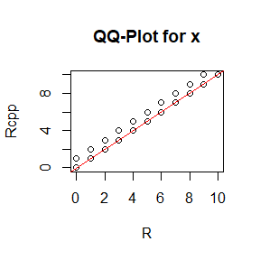

```r
# 参数设置
iterations <- 10000
n <- 10
a <- 2
b <- 3

# 运行Rcpp和R函数
set.seed(123)
samples_rcpp <- gibbsRcpp(iterations, n, a, b)

set.seed(123)
samples_r <- gibbsR(iterations, n, a, b)

#使用qqplot比较结果
# 比较x分量
qqplot(samples_r[, 1], samples_rcpp[, 1], main = "QQ-Plot for x", xlab = "R", ylab = "Rcpp")
abline(0, 1, col = "red")
```

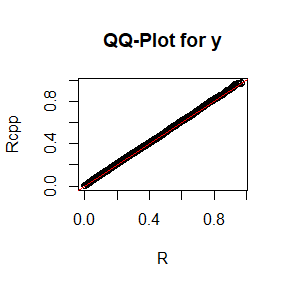

```r
# 比较y分量
qqplot(samples_r[, 2], samples_rcpp[, 2], main = "QQ-Plot for y", xlab = "R", ylab = "Rcpp")
abline(0, 1, col = "red")
```

# 比较计算时间

```r
library(microbenchmark)

# 比较时间
timing <- microbenchmark(
  R = gibbsR(iterations, n, a, b),
  Rcpp = gibbsRcpp(iterations, n, a, b),
  times = 10
)
print(timing)
```

```
## Unit: milliseconds
##  expr     min        lq      mean    median        uq       max neval cld
##     R 20.3409 20.615801 22.894991 22.285351 23.502900 31.262901    10  a
##  Rcpp  2.3865  2.408101  2.559711  2.425151  2.650001  3.287201    10   b
```

# comment

结果对比：

根据microbenchmark的结果，Rcpp的计算时间显著低于R函数，说明Rcpp在性能优化上具有明显优势。 总结：

Rcpp在处理大量迭代时表现出色，适合需要高效计算的场景。 如果仅处理小规模问题，R函数更为便捷。